# Assignment 3

Jocelyn Tsai

9/21/2020

```r
library(tidyverse)
library(ggplot2)
```

```r
US_data <- read_csv("wildfire_dataset.csv")
attach(US_data)
```

### Topic:

I want to explore the relationship between annual rainfall, mean annual temperature, Number of wildfires, number of acres burned, years with extreme heat wave, and years with high unemployment in the United States, looking at the years 1929 to 2015.

List of Variables:

1. Annual Rainfall in the US (continuous): Total_Rainfall_mm
2. Mean Annual Temperature in the US (continuous): Mean_Temp_Celsius
3. Number of Wildfires in the US each year (continuous): Num_Fires
4. Number of Acres Burned in the US each year (continuous): Acres_Burned
5. Years with Extreme Heat Wave in the US (categorical): Extreme_Heat_Wave
6. Years with High Unemployment in the US (categorical): High_Unemployment

## Relationships between continuous variables (correlation test)

### Correlation 1: Annual Rainfall and Mean Annual Temperature:

There is not a statistically significant relationship between annual rainfall and mean annual temperature as the 95 percent confidence interval crosses 0.

```r
correlation_1 <- cor.test(US_data$Total_Rainfall_mm, US_data$Mean_Temp_Celsius)
correlation_1
```

```
##
##  Pearson's product-moment correlation
##
## data:  US_data$Total_Rainfall_mm and US_data$Mean_Temp_Celsius
## t = 0.80943, df = 85, p-value = 0.4205
## alternative hypothesis: true correlation is not equal to 0
## 95 percent confidence interval:
##  -0.1255014  0.2927145
## sample estimates:
##        cor
## 0.08745894
```

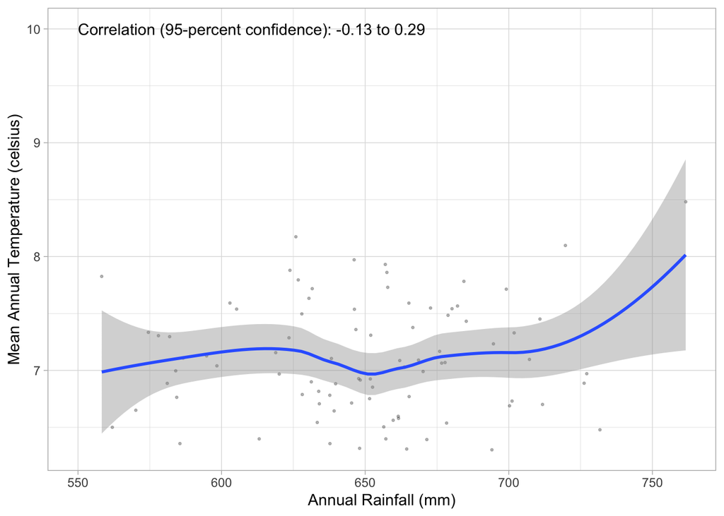

```r
ggplot(US_data, aes(x = Total_Rainfall_mm, y = Mean_Temp_Celsius)) +
  geom_point(size = 0.5, alpha = 0.25, position = "jitter") +
  geom_smooth() +
  theme_light() +
  scale_x_continuous(name = "Annual Rainfall (mm)")+
  scale_y_continuous(name = "Mean Annual Temperature (celsius)")+
  annotate(geom = "text", x = 550, y = 10,
           label = paste("Correlation (95-percent confidence):",
                         prettyNum(correlation_1$conf.int[1], digits = 2),
                         "to",
                         prettyNum(correlation_1$conf.int[2], digits = 2)),
           hjust = 0)
```

### Correlation 2: Annual Rainfall and Number of Wildfires in a year:

```r
correlation_2 <- cor.test(US_data$Total_Rainfall_mm, US_data$Num_Fires)
correlation_2
```

```
##
##  Pearson's product-moment correlation
##
## data:  US_data$Total_Rainfall_mm and US_data$Num_Fires
## t = -4.2355, df = 85, p-value = 5.752e-05
## alternative hypothesis: true correlation is not equal to 0
## 95 percent confidence interval:
##  -0.5773363 -0.2267483
## sample estimates:
##        cor
## -0.4174571
```

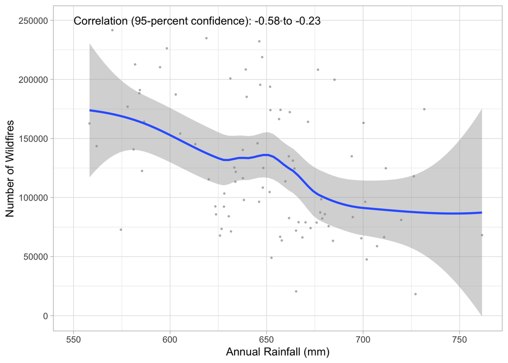

```r
ggplot(US_data, aes(x = Total_Rainfall_mm, y = Num_Fires)) +
  geom_point(size = 0.5, alpha = 0.25, position = "jitter") +
  geom_smooth() +
  theme_light() +
  scale_x_continuous(name = "Annual Rainfall (mm)")+
  scale_y_continuous(name = "Number of Wildfires")+
  annotate(geom = "text", x = 550, y = 250000,
           label = paste("Correlation (95-percent confidence):",
                         prettyNum(correlation_2$conf.int[1], digits = 2),
                         "to",
                         prettyNum(correlation_2$conf.int[2], digits = 2)),
           hjust = 0)
```

### Correlation 3: Annual Rainfall and Number of Acres Burned in a year:

Similar to the previous correlation, relationship between annual rainfall and number of acres burned in a year is also statistically significant because of a low p-value. There is a negative correlation as well.

```r
correlation_3 <- cor.test(US_data$Total_Rainfall_mm, US_data$Acres_Burned)
correlation_3
```

```
##
##  Pearson's product-moment correlation
##
## data:  US_data$Total_Rainfall_mm and US_data$Acres_Burned
## t = -3.5534, df = 85, p-value = 0.0006236
## alternative hypothesis: true correlation is not equal to 0
## 95 percent confidence interval:
##  -0.5301200 -0.1611945
## sample estimates:
##        cor
## -0.3596314
```

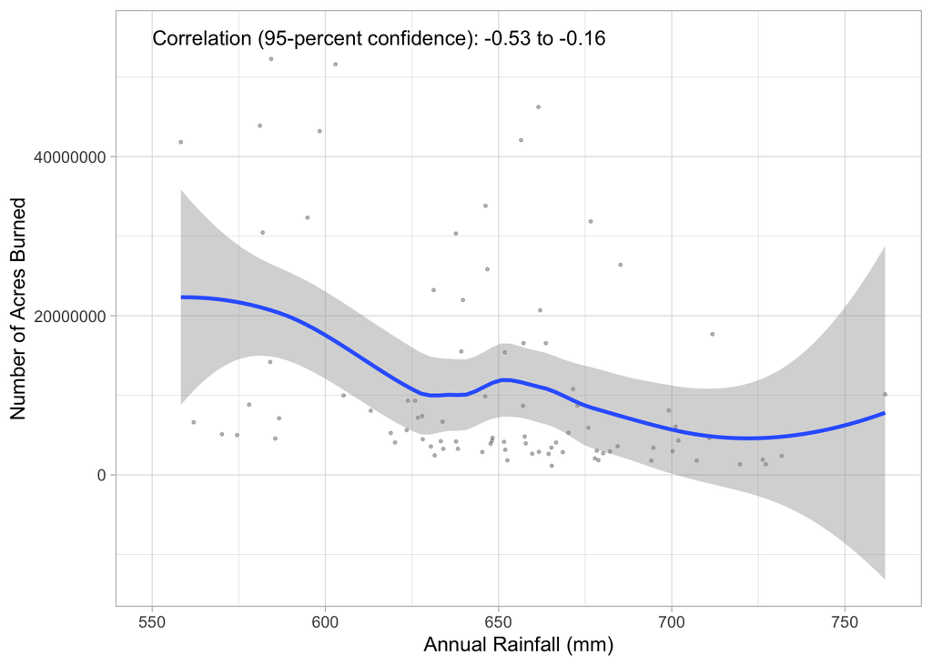

```r
options(scipen = 999)
ggplot(US_data, aes(x = Total_Rainfall_mm, y = Acres_Burned)) +
  geom_point(size = 0.5, alpha = 0.25, position = "jitter") +
  geom_smooth() +
  theme_light() +
  scale_x_continuous(name = "Annual Rainfall (mm)")+
  scale_y_continuous(name = "Number of Acres Burned")+
  annotate(geom = "text", x = 550, y = 55000000,
           label = paste("Correlation (95-percent confidence):",
                         prettyNum(correlation_3$conf.int[1], digits = 2),
                         "to",
                         prettyNum(correlation_3$conf.int[2], digits = 2)),
           hjust = 0)
```

### Correlation 4: Mean Annual Temperature and Number of Wildfires in a year:

The most surprising correlation that I found was that there is a weak, but statistically significant relationship between mean annual temperature and number of wildfires in a year. I would expect that there are more wildfires during years that have a higher mean annual temperature but the results show the opposite. There is a negative correlation at a 95-percent confidence level, which indicates that when mean annual temperature is higher, there are fewer number of wildfires in the US. However, this could be because I only had 87 years of data, and there are outliers skewing the representation.

```r
correlation_4 <- cor.test(US_data$Mean_Temp_Celsius, US_data$Num_Fires)
correlation_4
```

```
##
##  Pearson's product-moment correlation
##
## data:  US_data$Mean_Temp_Celsius and US_data$Num_Fires
## t = -2.3649, df = 85, p-value = 0.02031
## alternative hypothesis: true correlation is not equal to 0
## 95 percent confidence interval:
##  -0.43628320 -0.03991056
## sample estimates:
##        cor
## -0.2484699
```

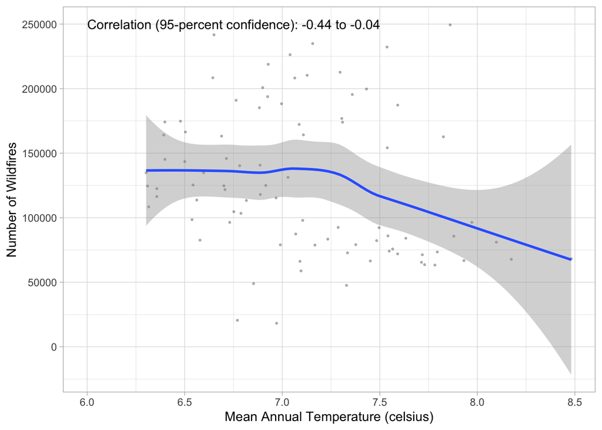

```r
ggplot(US_data, aes(x = Mean_Temp_Celsius, y = Num_Fires)) +
  geom_point(size = 0.5, alpha = 0.25, position = "jitter") +
  geom_smooth() +
  theme_light() +
  scale_x_continuous(name = "Mean Annual Temperature (celsius)")+
  scale_y_continuous(name = "Number of Wildfires")+
  annotate(geom = "text", x = 6, y = 250000,
           label = paste("Correlation (95-percent confidence):",
                         prettyNum(correlation_4$conf.int[1], digits = 2),
                         "to",
                         prettyNum(correlation_4$conf.int[2], digits = 2)),
           hjust = 0)
```

### Correlation 5: Mean Annual Temperature and Number of Acres Burned in a year:

The relationship between mean annual temperature and acres burned a year is not statistically significant and there is no correlation.

```r
correlation_5 <- cor.test(US_data$Mean_Temp_Celsius, US_data$Acres_Burned)
correlation_5
```

```
##
##  Pearson's product-moment correlation
##
## data:  US_data$Mean_Temp_Celsius and US_data$Acres_Burned
## t = -0.0159, df = 85, p-value = 0.9874
## alternative hypothesis: true correlation is not equal to 0
## 95 percent confidence interval:
##  -0.2122957  0.2089996
## sample estimates:
##          cor
## -0.001724591
```

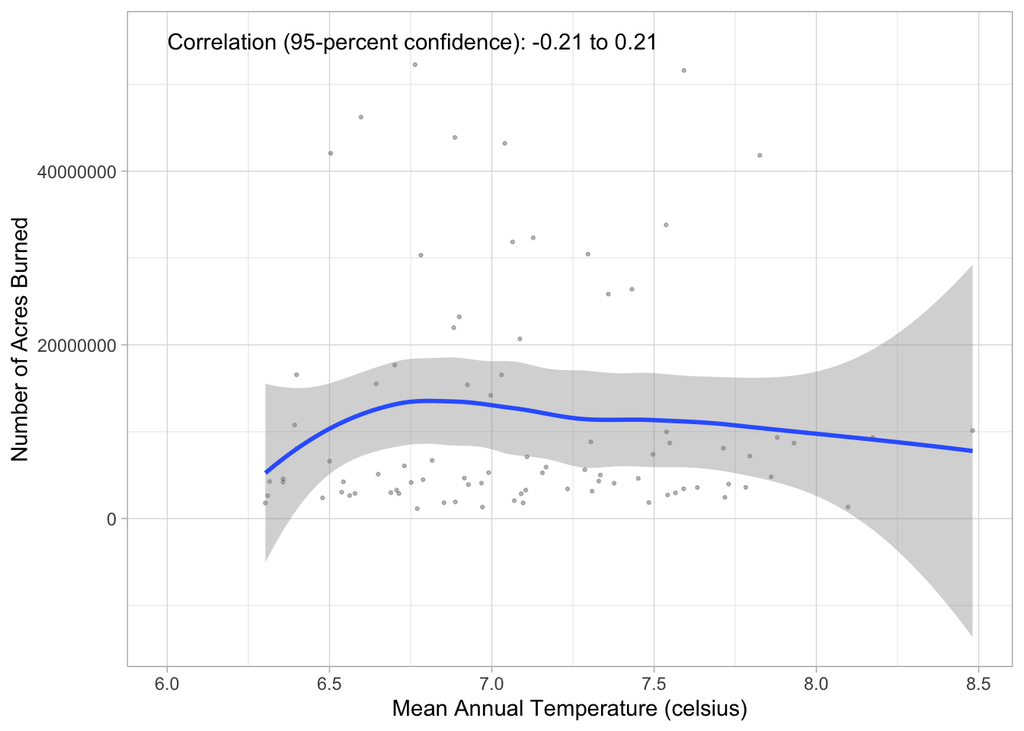

```r
options(scipen = 999)
ggplot(US_data, aes(x = Mean_Temp_Celsius, y = Acres_Burned)) +
  geom_point(size = 0.5, alpha = 0.25, position = "jitter") +
  geom_smooth() +
  theme_light() +
  scale_x_continuous(name = "Mean Annual Temperature (celsius)")+
  scale_y_continuous(name = "Number of Acres Burned")+
  annotate(geom = "text", x = 6, y = 55000000,
           label = paste("Correlation (95-percent confidence):",
                         prettyNum(correlation_5$conf.int[1], digits = 2),
                         "to",
                         prettyNum(correlation_5$conf.int[2], digits = 2)),
           hjust = 0)
```

### Correlation 6: Number of Wildfires and Number of Acres Burned in a year:

There is a clear, positive correlation between number of wildfires and number of acres burned. P-value is extremely small, and correlation is 0.5. More wildfires generally indicate more acres burned in a year.

```r
correlation_6 <- cor.test(US_data$Num_Fires, US_data$Acres_Burned)
correlation_6
```

```
##
##  Pearson's product-moment correlation
##
## data:  US_data$Num_Fires and US_data$Acres_Burned
## t = 5.8304, df = 85, p-value = 0.00000009703
## alternative hypothesis: true correlation is not equal to 0
## 95 percent confidence interval:
##  0.3649228 0.6697295
## sample estimates:
##      cor
## 0.534485
```

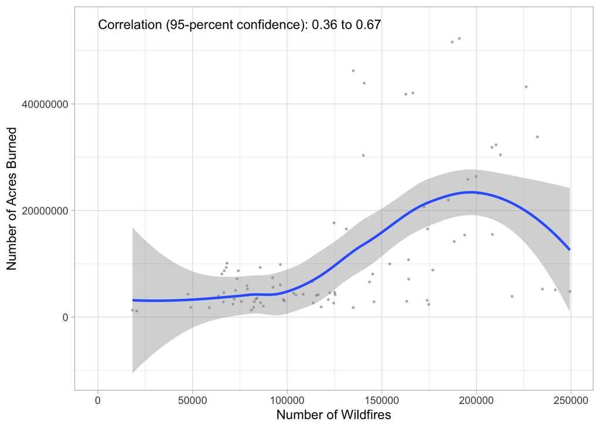

```r
options(scipen = 999)
ggplot(US_data, aes(x = Num_Fires, y = Acres_Burned)) +
  geom_point(size = 0.5, alpha = 0.25, position = "jitter") +
  geom_smooth() +
  theme_light() +
  scale_x_continuous(name = "Number of Wildfires")+
  scale_y_continuous(name = "Number of Acres Burned")+
  annotate(geom = "text", x = 0, y = 55000000,
           label = paste("Correlation (95-percent confidence):",
                         prettyNum(correlation_6$conf.int[1], digits = 2),
                         "to",
                         prettyNum(correlation_6$conf.int[2], digits = 2)),
           hjust = 0)
```

## Relationship between a continuous variable and a binary variable (two-sample t.test)

### Extreme Heat Wave and continuous variables:

Difference 1: Do years with extreme heat wave have a higher or lower annual rainfall than years without extreme heat wave?

Finding: Statistically significant. Years with extreme heat wave have lower annual rainfall.

```r
difference_1 = t.test(Total_Rainfall_mm ~ Extreme_Heat_Wave,
                    data = US_data)
difference_1
```

```
##
##  Welch Two Sample t-test
##
## data:  Total_Rainfall_mm by Extreme_Heat_Wave
## t = 4.4435, df = 15.728, p-value = 0.0004249
## alternative hypothesis: true difference in means is not equal to 0
## 95 percent confidence interval:
##  25.67962 72.66269
## sample estimates:
## mean in group FALSE  mean in group TRUE
##            656.4941            607.3229
```

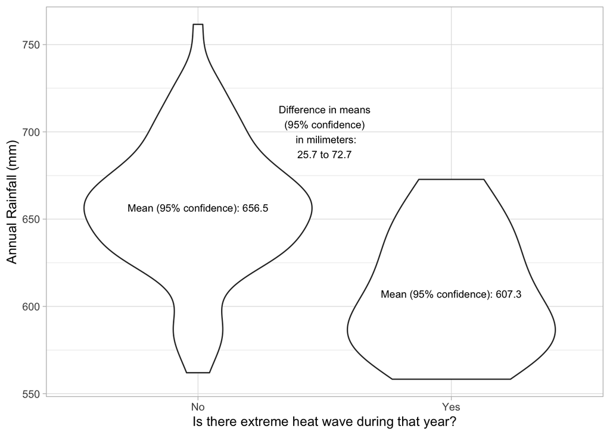

```r
ggplot(US_data, aes(x = Extreme_Heat_Wave, y = Total_Rainfall_mm)) +
  geom_violin() +
  theme_light() +
  scale_x_discrete(name = "Is there extreme heat wave during that year?",
                   labels = c("No", "Yes")) +
  scale_y_continuous(name = "Annual Rainfall (mm)")+
  annotate(geom = "text", x = 1.5, y = 700, size = 3,
           label = paste("Difference in means\n(95% confidence)\n in milimeters:\n",
                         prettyNum(abs(difference_1$conf.int[1]),
                                   digits = 3), " to ",
                         prettyNum(abs(difference_1$conf.int[2]),
                                   digits = 3),
                         sep = "")) +
  annotate(geom = "text", x = 1, y = difference_1$estimate[1], size = 3,
           label = paste("Mean (95% confidence):",
                         prettyNum(difference_1$estimate[1], digits = 4))) +
  annotate(geom = "text", x = 2, y = difference_1$estimate[2], size = 3,
           label = paste("Mean (95% confidence):",
                         prettyNum(difference_1$estimate[2], digits = 4)))
```

Difference 2: Do years with extreme heat wave have a higher or lower mean annual temperature than years without extreme heat wave?

Finding: Statistically significant. Years with extreme heat wave have higher mean annual temperature.

```r
difference_2 = t.test(Mean_Temp_Celsius ~ Extreme_Heat_Wave,
                    data = US_data)
difference_2
```

```
##
##  Welch Two Sample t-test
##
## data:  Mean_Temp_Celsius by Extreme_Heat_Wave
## t = -2.6207, df = 15.978, p-value = 0.01856
## alternative hypothesis: true difference in means is not equal to 0
## 95 percent confidence interval:
##  -0.64756145 -0.06836774
## sample estimates:
## mean in group FALSE  mean in group TRUE
##            7.055010            7.412974
```

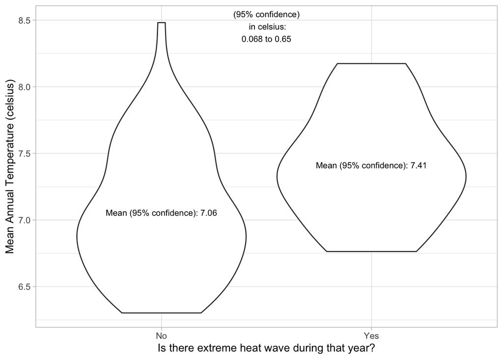

```r
ggplot(US_data, aes(x = Extreme_Heat_Wave, y = Mean_Temp_Celsius)) +
  geom_violin() +
  theme_light() +
  scale_x_discrete(name = "Is there extreme heat wave during that year?",
                   labels = c("No", "Yes")) +
  scale_y_continuous(name = "Mean Annual Temperature (celsius)")+
  annotate(geom = "text", x = 1.5, y = 8.5, size = 3,
           label = paste("Difference in means\n(95% confidence)\n in celsius:\n",
                         prettyNum(abs(difference_2$conf.int[2]),
                                   digits = 2), " to ",
                         prettyNum(abs(difference_2$conf.int[1]),
                                   digits = 2),
                         sep = "")) +
  annotate(geom = "text", x = 1, y = difference_2$estimate[1], size = 3,
           label = paste("Mean (95% confidence):",
                         prettyNum(difference_2$estimate[1], digits = 3))) +
  annotate(geom = "text", x = 2, y = difference_2$estimate[2], size = 3,
           label = paste("Mean (95% confidence):",
                         prettyNum(difference_2$estimate[2], digits = 3)))
```

Difference 3: Do years with extreme heat wave have a higher or lower number of wildfires than years without extreme heat wave?

Finding: Statistically insignificant.

```r
difference_3 = t.test(Num_Fires ~ Extreme_Heat_Wave,
                    data = US_data)
difference_3
```

```
##
##  Welch Two Sample t-test
##
## data:  Num_Fires by Extreme_Heat_Wave
## t = -1.5847, df = 13.99, p-value = 0.1354
## alternative hypothesis: true difference in means is not equal to 0
## 95 percent confidence interval:
##  -69357.62  10417.40
## sample estimates:
## mean in group FALSE  mean in group TRUE
##            122705.6            152175.8
```

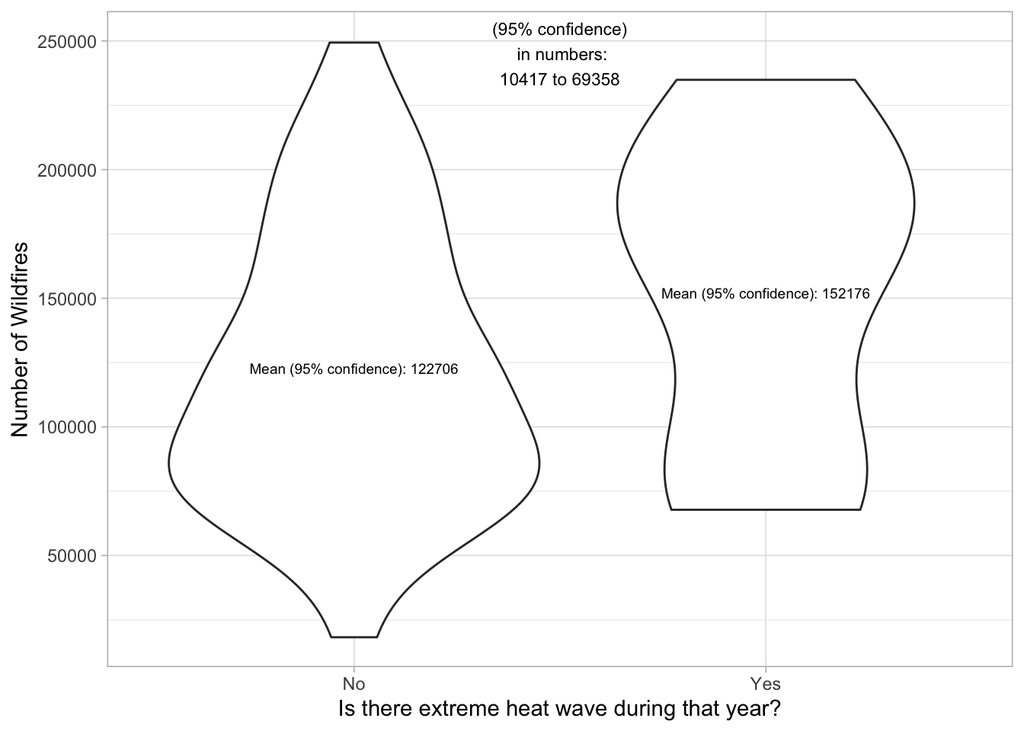

```r
ggplot(US_data, aes(x = Extreme_Heat_Wave, y = Num_Fires)) +
  geom_violin() +
  theme_light() +
  scale_x_discrete(name = "Is there extreme heat wave during that year?",
                   labels = c("No", "Yes")) +
  scale_y_continuous(name = "Number of Wildfires")+
  annotate(geom = "text", x = 1.5, y = 250000, size = 3,
           label = paste("Difference in means\n(95% confidence)\n in numbers:\n",
                         prettyNum(abs(difference_3$conf.int[2]),
                                   digits = 2), " to ",
                         prettyNum(abs(difference_3$conf.int[1]),
                                   digits = 2),
                         sep = "")) +
  annotate(geom = "text", x = 1, y = difference_3$estimate[1], size = 2.5,
           label = paste("Mean (95% confidence):",
                         prettyNum(difference_3$estimate[1], digits = 3))) +
  annotate(geom = "text", x = 2, y = difference_3$estimate[2], size = 2.5,
           label = paste("Mean (95% confidence):",
                         prettyNum(difference_3$estimate[2], digits = 3)))
```

Difference 4: Do years with extreme heat wave have a higher or lower number of acres burned than years without extreme heat wave?

Finding: Statistically significant. Years with extreme heat wave have more number of acres burned.

```r
difference_4 = t.test(Acres_Burned ~ Extreme_Heat_Wave,
                    data = US_data)
difference_4
```

```
##
##  Welch Two Sample t-test
##
## data:  Acres_Burned by Extreme_Heat_Wave
## t = -2.8133, df = 11.976, p-value = 0.01568
## alternative hypothesis: true difference in means is not equal to 0
## 95 percent confidence interval:
##  -28806721  -3657974
## sample estimates:
## mean in group FALSE  mean in group TRUE
##             9238775            25471122
```

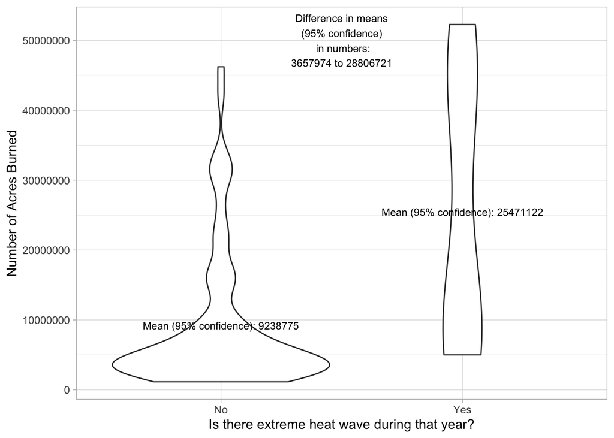

```r
ggplot(US_data, aes(x = Extreme_Heat_Wave, y = Acres_Burned)) +
  geom_violin() +
  theme_light() +
  scale_x_discrete(name = "Is there extreme heat wave during that year?",
                   labels = c("No", "Yes")) +
  scale_y_continuous(name = "Number of Acres Burned")+
  annotate(geom = "text", x = 1.5, y = 50000000, size = 3,
           label = paste("Difference in means\n(95% confidence)\n in numbers:\n",
                         prettyNum(abs(difference_4$conf.int[2]),
                                   digits = 2), " to ",
                         prettyNum(abs(difference_4$conf.int[1]),
                                   digits = 2),
                         sep = "")) +
  annotate(geom = "text", x = 1, y = difference_4$estimate[1], size = 3,
           label = paste("Mean (95% confidence):",
                         prettyNum(difference_4$estimate[1], digits = 3))) +
  annotate(geom = "text", x = 2, y = difference_4$estimate[2], size = 3,
           label = paste("Mean (95% confidence):",
                         prettyNum(difference_4$estimate[2], digits = 3)))
```

### High Unemployment and continuous variables:

Difference 5: Do years with high unemployment rate have a higher or lower annual rainfall than years without high unemployment rate?

Finding: Statistically insignificant.

```r
difference_5 = t.test(Total_Rainfall_mm ~ High_Unemployment,
                    data = US_data)
difference_5
```

```
##
##  Welch Two Sample t-test
##
## data:  Total_Rainfall_mm by High_Unemployment
## t = -0.65527, df = 53.496, p-value = 0.5151
## alternative hypothesis: true difference in means is not equal to 0
## 95 percent confidence interval:
##  -26.18388  13.28637
## sample estimates:
## mean in group FALSE  mean in group TRUE
##            645.4868            651.9356
```

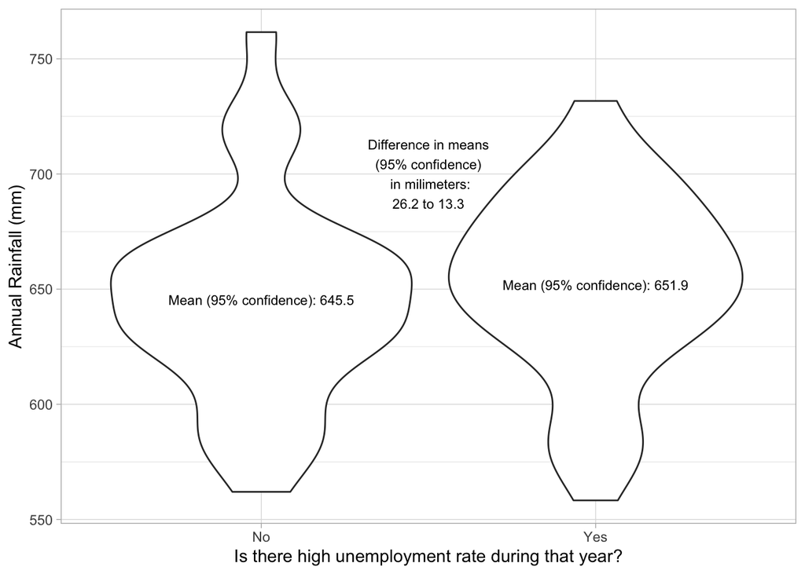

```r
ggplot(US_data, aes(x = High_Unemployment, y = Total_Rainfall_mm)) +
  geom_violin() +
  theme_light() +
  scale_x_discrete(name = "Is there high unemployment rate during that year?",
                   labels = c("No", "Yes")) +
  scale_y_continuous(name = "Annual Rainfall (mm)")+
  annotate(geom = "text", x = 1.5, y = 700, size = 3,
           label = paste("Difference in means\n(95% confidence)\n in milimeters:\n",
                         prettyNum(abs(difference_5$conf.int[1]),
                                   digits = 3), " to ",
                         prettyNum(abs(difference_5$conf.int[2]),
                                   digits = 3),
                         sep = "")) +
  annotate(geom = "text", x = 1, y = difference_5$estimate[1], size = 3,
           label = paste("Mean (95% confidence):",
                         prettyNum(difference_5$estimate[1], digits = 4))) +
  annotate(geom = "text", x = 2, y = difference_5$estimate[2], size = 3,
           label = paste("Mean (95% confidence):",
                         prettyNum(difference_5$estimate[2], digits = 4)))
```

Difference 6: Do years with high unemployment rate have a higher or lower mean annual temperature than years without high unemployment rate?

Finding: Statistically insignificant.

```r
difference_6 = t.test(Mean_Temp_Celsius ~ High_Unemployment,
                    data = US_data)
difference_6
```

```
##
##  Welch Two Sample t-test
##
## data:  Mean_Temp_Celsius by High_Unemployment
## t = -0.7468, df = 48.079, p-value = 0.4588
## alternative hypothesis: true difference in means is not equal to 0
## 95 percent confidence interval:
##  -0.3344247  0.1532730
## sample estimates:
## mean in group FALSE  mean in group TRUE
##            7.045041            7.135617
```

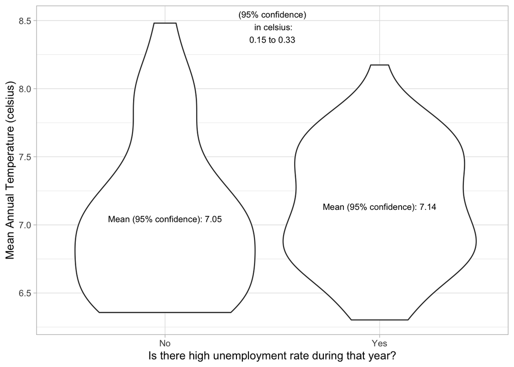

```r
ggplot(US_data, aes(x = High_Unemployment, y = Mean_Temp_Celsius)) +
  geom_violin() +
  theme_light() +
  scale_x_discrete(name = "Is there high unemployment rate during that year?",
                   labels = c("No", "Yes")) +
  scale_y_continuous(name = "Mean Annual Temperature (celsius)")+
  annotate(geom = "text", x = 1.5, y = 8.5, size = 3,
           label = paste("Difference in means\n(95% confidence)\n in celsius:\n",
                         prettyNum(abs(difference_6$conf.int[2]),
                                   digits = 2), " to ",
                         prettyNum(abs(difference_6$conf.int[1]),
                                   digits = 2),
                         sep = "")) +
  annotate(geom = "text", x = 1, y = difference_6$estimate[1], size = 3,
           label = paste("Mean (95% confidence):",
                         prettyNum(difference_6$estimate[1], digits = 3))) +
  annotate(geom = "text", x = 2, y = difference_6$estimate[2], size = 3,
           label = paste("Mean (95% confidence):",
                         prettyNum(difference_6$estimate[2], digits = 3)))
```

Difference 7: Do years with high unemployment rate have a higher or lower number of wildfires than years without high unemployment rate?

Finding: Statistically insignificant.

```r
difference_7 = t.test(Num_Fires ~ High_Unemployment,
                    data = US_data)
difference_7
```

```
##
##  Welch Two Sample t-test
##
## data:  Num_Fires by High_Unemployment
## t = 0.96823, df = 77.016, p-value = 0.336
## alternative hypothesis: true difference in means is not equal to 0
## 95 percent confidence interval:
##  -11678.37  33784.36
## sample estimates:
## mean in group FALSE  mean in group TRUE
##            134012.1            122959.1
```

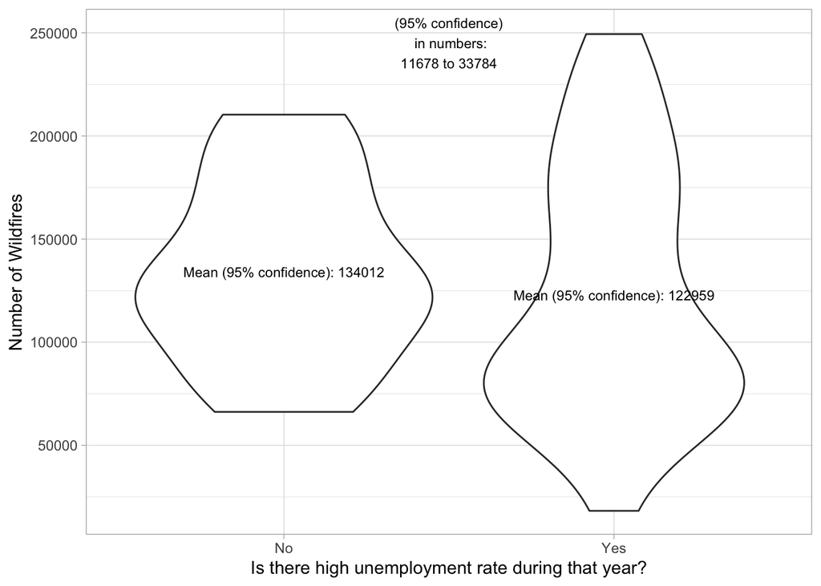

```r
ggplot(US_data, aes(x = High_Unemployment, y = Num_Fires)) +
  geom_violin() +
  theme_light() +
  scale_x_discrete(name = "Is there high unemployment rate during that year?",
                   labels = c("No", "Yes")) +
  scale_y_continuous(name = "Number of Wildfires")+
  annotate(geom = "text", x = 1.5, y = 250000, size = 3,
           label = paste("Difference in means\n(95% confidence)\n in numbers:\n",
                         prettyNum(abs(difference_7$conf.int[1]),
                                   digits = 2)," to ",
                         prettyNum(abs(difference_7$conf.int[2]),
                                   digits = 2),
                         sep = "")) +
  annotate(geom = "text", x = 1, y = difference_7$estimate[1], size = 3,
           label = paste("Mean (95% confidence):",
                         prettyNum(difference_7$estimate[1], digits = 3))) +
  annotate(geom = "text", x = 2, y = difference_7$estimate[2], size = 3,
           label = paste("Mean (95% confidence):",
                         prettyNum(difference_7$estimate[2], digits = 3)))
```

Difference 8: Do years with high unemployment rate have a higher or lower number of acres burned than years without high unemployment rate?

Finding: Statistically insignificant.

```r
difference_8 = t.test(Acres_Burned ~ High_Unemployment,
                    data = US_data)
difference_8
```

```
##
##  Welch Two Sample t-test
##
## data:  Acres_Burned by High_Unemployment
## t = 0.35976, df = 77.097, p-value = 0.72
## alternative hypothesis: true difference in means is not equal to 0
## 95 percent confidence interval:
##  -4361046  6284382
## sample estimates:
## mean in group FALSE  mean in group TRUE
##            12107777            11146110
```

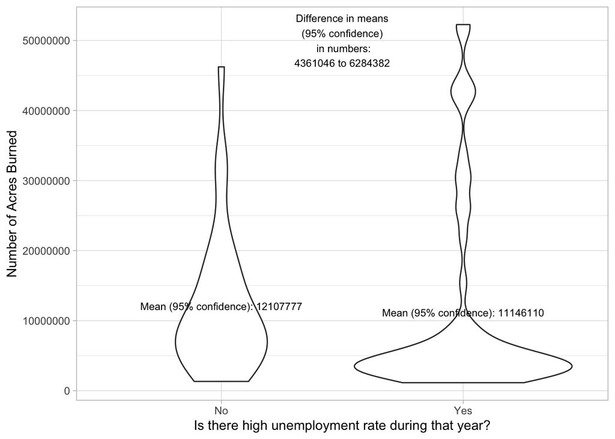

```r
ggplot(US_data, aes(x = High_Unemployment, y = Acres_Burned)) +
  geom_violin() +
  theme_light() +
  scale_x_discrete(name = "Is there high unemployment rate during that year?",
                   labels = c("No", "Yes")) +
  scale_y_continuous(name = "Number of Acres Burned")+
  annotate(geom = "text", x = 1.5, y = 50000000, size = 3,
           label = paste("Difference in means\n(95% confidence)\n in numbers:\n",
                         prettyNum(abs(difference_8$conf.int[1]),
                                   digits = 2), " to ",
                         prettyNum(abs(difference_8$conf.int[2]),
                                   digits = 2),
                         sep = "")) +
  annotate(geom = "text", x = 1, y = difference_8$estimate[1], size = 3,
           label = paste("Mean (95% confidence):",
                         prettyNum(difference_8$estimate[1], digits = 3))) +
  annotate(geom = "text", x = 2, y = difference_8$estimate[2], size = 3,
           label = paste("Mean (95% confidence):",
                         prettyNum(difference_8$estimate[2], digits = 3)))
```

## Relationship between two categorical variables (Chi-Squared Test)

### Years with Extreme Heat Wave and Years with High Unemployment Rate

There is a warning that my Chi-Squared approximation may be incorrect because in my observed data shown below, there’s only 2 values (two years) that have extreme heat waves but do not have high unemployment. For the Chi-Squared Test to be accurate, there needs to be no less than 5 values in each category. However, since the p-value is 0.284, which is a lot higher than 0.05, it is safe to say that the relationship between the two categorical variables is insignificant.

```r
chi_sq_1 <- chisq.test(US_data$High_Unemployment, US_data$Extreme_Heat_Wave)
```

```
## Warning in chisq.test(US_data$High_Unemployment, US_data$Extreme_Heat_Wave):
## Chi-squared approximation may be incorrect
```

```r
chi_sq_1
```

```
##
##  Pearson's Chi-squared test with Yates' continuity correction
##
## data:  US_data$High_Unemployment and US_data$Extreme_Heat_Wave
## X-squared = 1.1479, df = 1, p-value = 0.284
```

```r
chi_sq_1$observed
```

```
##                          US_data$Extreme_Heat_Wave
## US_data$High_Unemployment FALSE TRUE
##                     FALSE    28    2
##                     TRUE     47   10
```

```r
chi_sq_1$expected
```

```
##                          US_data$Extreme_Heat_Wave
## US_data$High_Unemployment    FALSE     TRUE
##                     FALSE 25.86207 4.137931
##                     TRUE  49.13793 7.862069
```